# Modelling Approaches, Example 1

J. Zeldin

September 14, 2018

### Demonstrating Some Modeling Approaches Using CO2 uptake data from grassland plant species

```r
library(tidyverse);library(lme4)
```

#### Overview

In this module, we will use the built in dataset “CO2” to demonstrate some modeling approaches.

This data set consists of observations from six plants from Quebec and 6 from Mississippi. Half of the plants from each provenance were subjected to a chilling treatment. Each plants CO2 uptake rate was measured at 7 different CO2 concentrations.

We might be interested in understanding if the chilling treatment and/or CO2 concentration influences CO2 uptake rate. Let’s explore the data and try some modeling approaches to understand what is happening in the experiment.

#### Data Exploration

First let’s explore the data using some visualization techniques and summary statistics.

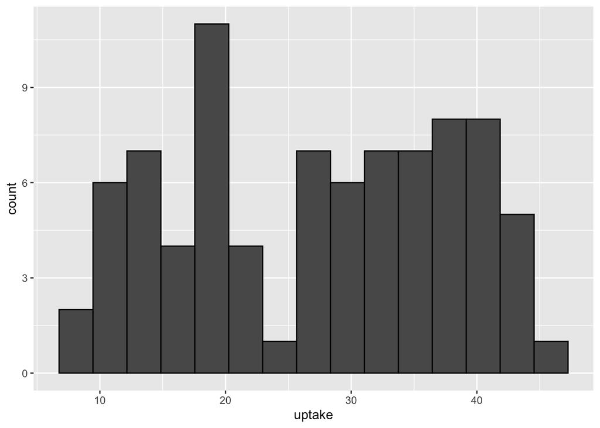

```r
# The distribution of our response variable
CO2 %>%
  ggplot(aes(uptake))+
  geom_histogram(bins = 15, color = "black")
```

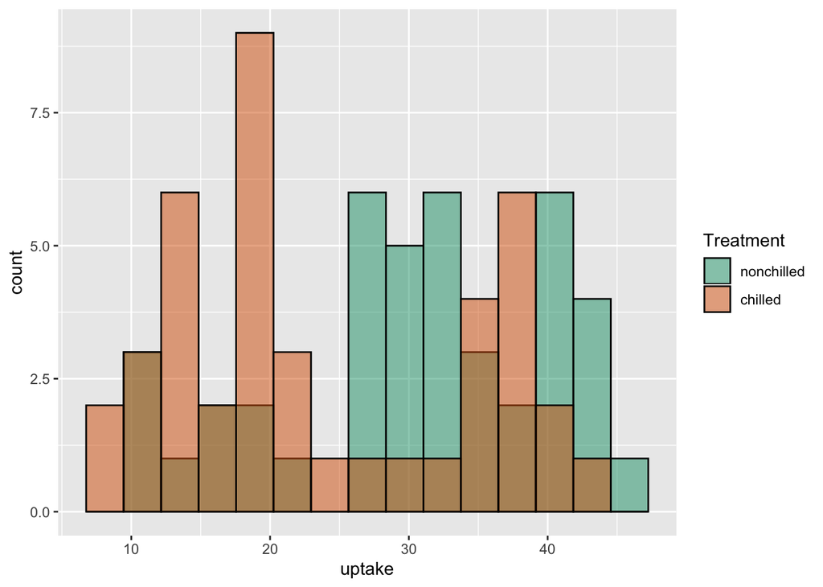

```r
  # Not quite normally distributed... almost bimodal. Let's include some     other independant variables
CO2 %>%
  ggplot(aes(uptake, fill = Treatment))+
  geom_histogram(position = "identity",alpha = 0.5,
                 bins = 15, color = "black")+
  scale_fill_brewer(palette = "Dark2")
```

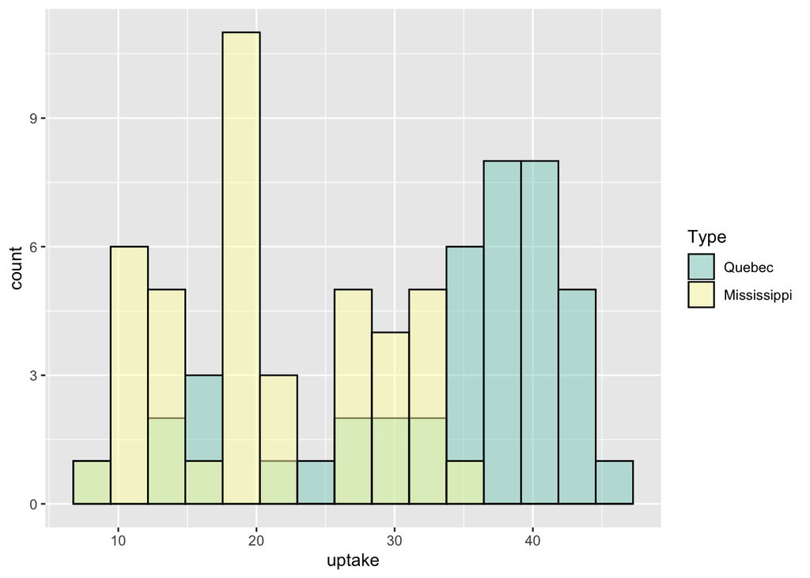

```r
CO2 %>%
  ggplot(aes(uptake, fill = Type))+
  geom_histogram(position = "identity",alpha = 0.5,
                 bins = 15, color = "black")+
  scale_fill_brewer(palette = "Set3")
```

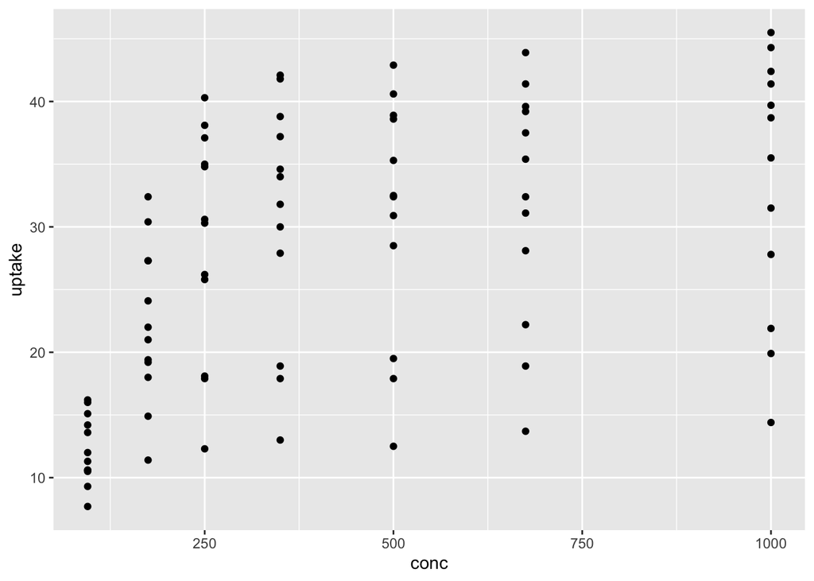

```r
  # The plant origin may be driving the bimodal distribution

# Visualize the relationship b/w concentration and uptake
CO2 %>%
  ggplot(aes(conc,uptake))+
  geom_point()
```

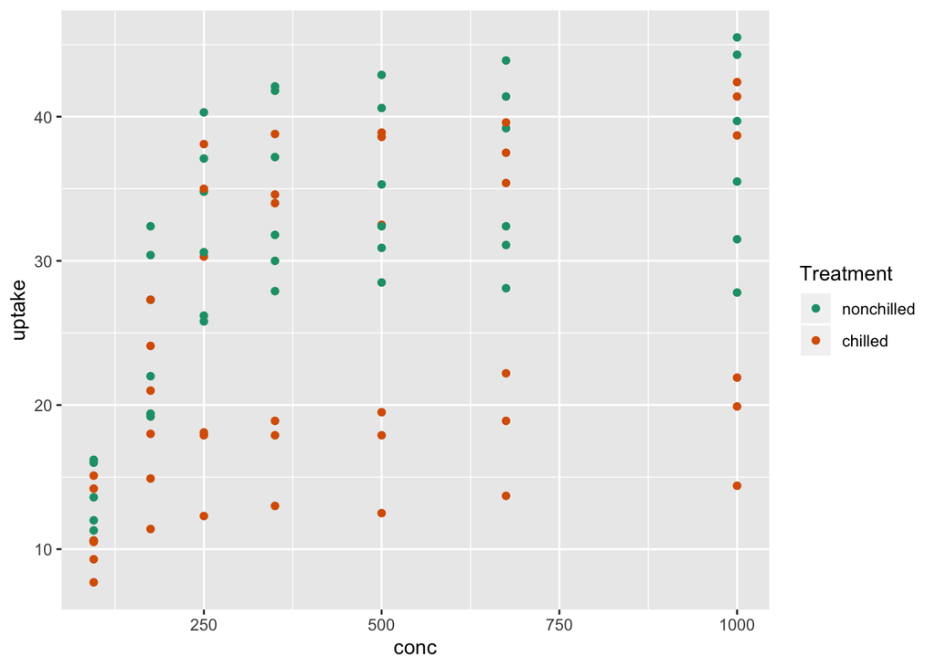

```r
# Add independant variables
CO2 %>%
  ggplot(aes(conc,uptake, color = Treatment))+
  geom_point()+
  scale_color_brewer(palette = "Dark2")
```

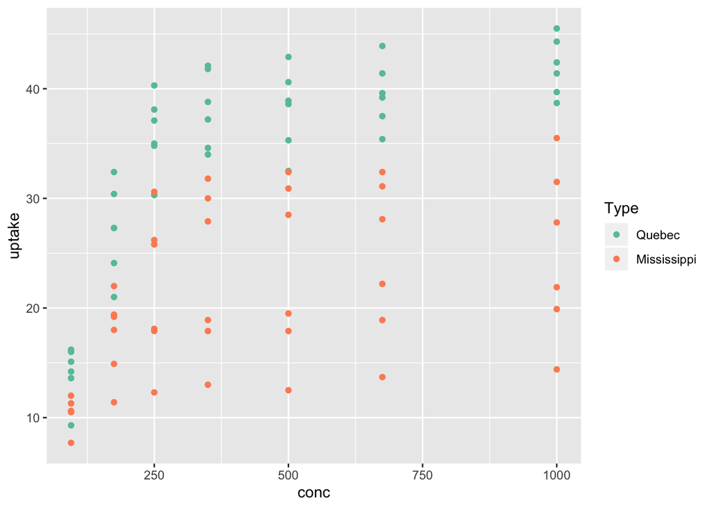

```r
CO2 %>%
  ggplot(aes(conc,uptake, color = Type))+
  geom_point()+
  scale_color_brewer(palette = "Set2")
```

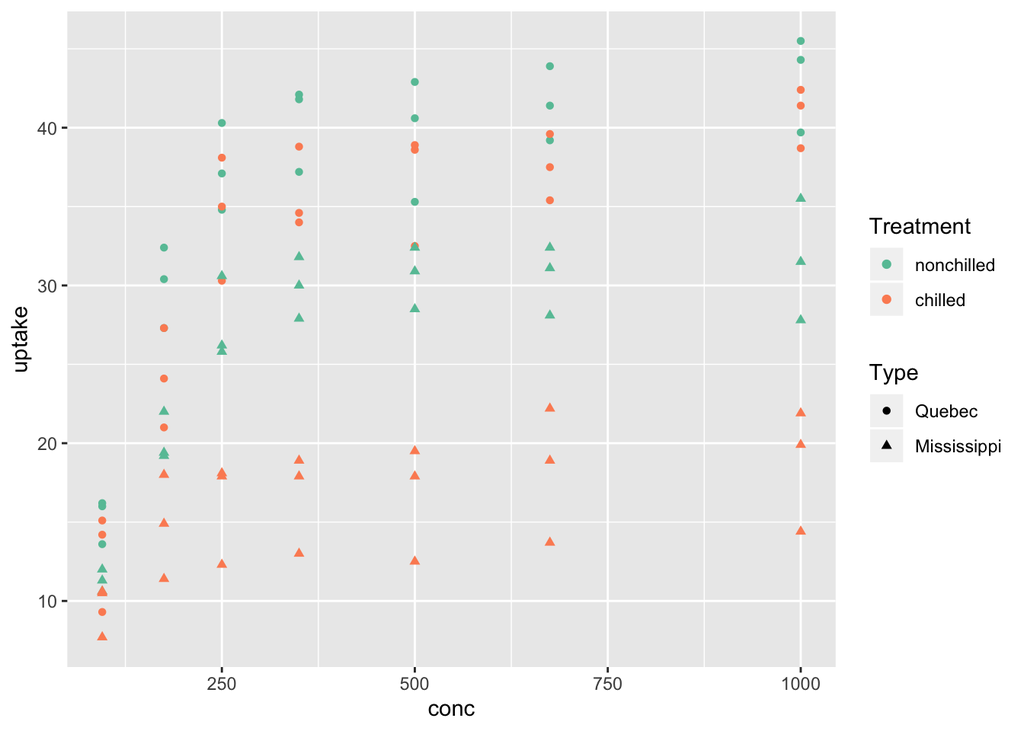

```r
CO2 %>%
  ggplot(aes(conc,uptake, shape = Type, color = Treatment))+
  geom_point()+
  scale_color_brewer(palette = "Set2")
```

Let’s building some models. We will start with a simple linear regression of uptake ~ conentration

```r
lm_1 <- lm(uptake ~ conc, data = CO2)
summary(lm_1)
```

```
##
## Call:
## lm(formula = uptake ~ conc, data = CO2)
##
## Residuals:
##     Min      1Q  Median      3Q     Max
## -22.831  -7.729   1.483   7.748  16.394
##
## Coefficients:
##              Estimate Std. Error t value Pr(>|t|)
## (Intercept) 19.500290   1.853080  10.523  < 2e-16 ***
## conc         0.017731   0.003529   5.024 2.91e-06 ***
## ---
## Signif. codes:  0 '***' 0.001 '**' 0.01 '*' 0.05 '.' 0.1 ' ' 1
##
## Residual standard error: 9.514 on 82 degrees of freedom
## Multiple R-squared:  0.2354, Adjusted R-squared:  0.2261
## F-statistic: 25.25 on 1 and 82 DF,  p-value: 2.906e-06
```

The summary output gives us a very significant p-value for the concentration term as well as for the F test of the overall model and the adjusted R2 is 0.23. There is quite a bit of unexplained variation in our data in this case. Let’s plot our model’s predictions and look at the residuals.

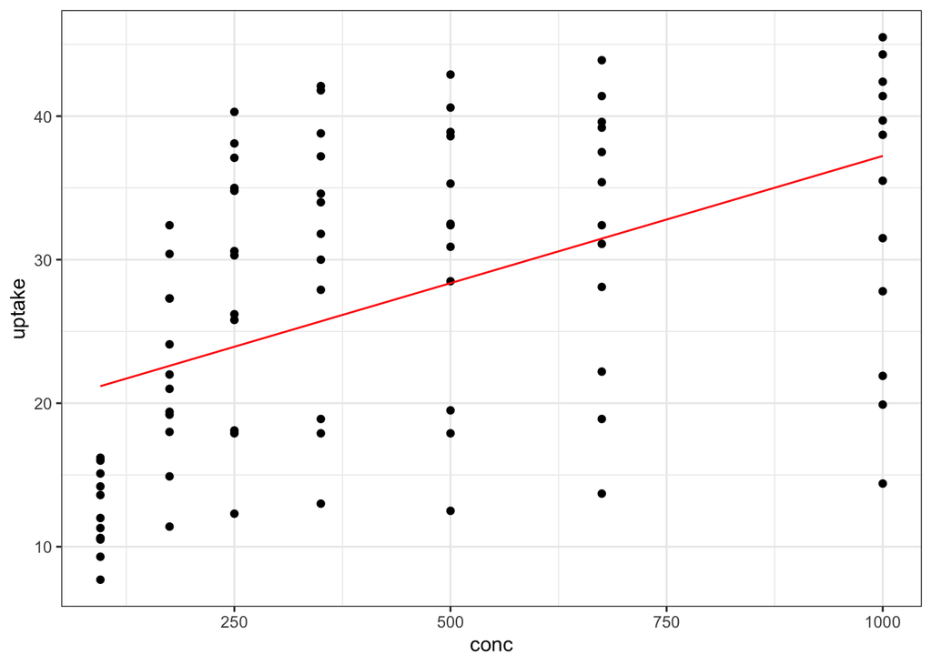

```r
library(broom)

lm_1 %>%
  augment() %>%
  ggplot(aes(conc,uptake))+
  geom_point()+
  geom_line(aes(conc,.fitted), color = "red")+
  theme_bw()
```

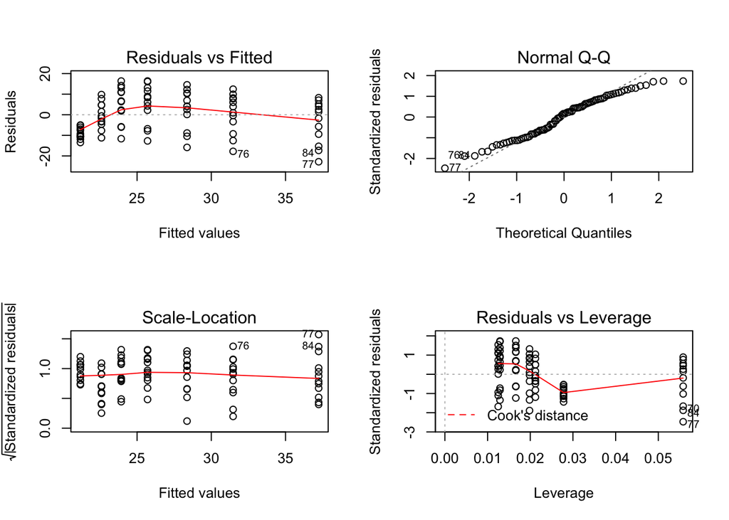

```r
par(mfrow=c(2,2))
plot(lm_1)
```

```r
par(mfrow=c(1,1))
```

From the plots above - it’s pretty clear that our model, while significant, is not doing a good job of describing our data.

```r
CO2 <- CO2 %>%
  mutate(log_conc = log(conc))

em_1 <- lm(uptake ~ log_conc, data = CO2)
summary(em_1)
```

```
##
## Call:
## lm(formula = uptake ~ log_conc, data = CO2)
##
## Residuals:
##      Min       1Q   Median       3Q      Max
## -22.0474  -5.9024   0.3495   6.4662  15.6138
##
## Coefficients:
##             Estimate Std. Error t value Pr(>|t|)
## (Intercept)  -22.157      7.475  -2.964  0.00397 **
## log_conc       8.484      1.274   6.659 2.92e-09 ***
## ---
## Signif. codes:  0 '***' 0.001 '**' 0.01 '*' 0.05 '.' 0.1 ' ' 1
##
## Residual standard error: 8.765 on 82 degrees of freedom
## Multiple R-squared:  0.351,  Adjusted R-squared:  0.3431
## F-statistic: 44.34 on 1 and 82 DF,  p-value: 2.915e-09
```

The summary tells a similar story, significant concentration term, F-test, but now we have a higher adjusted R2 of 0.34. Let’s plot it out

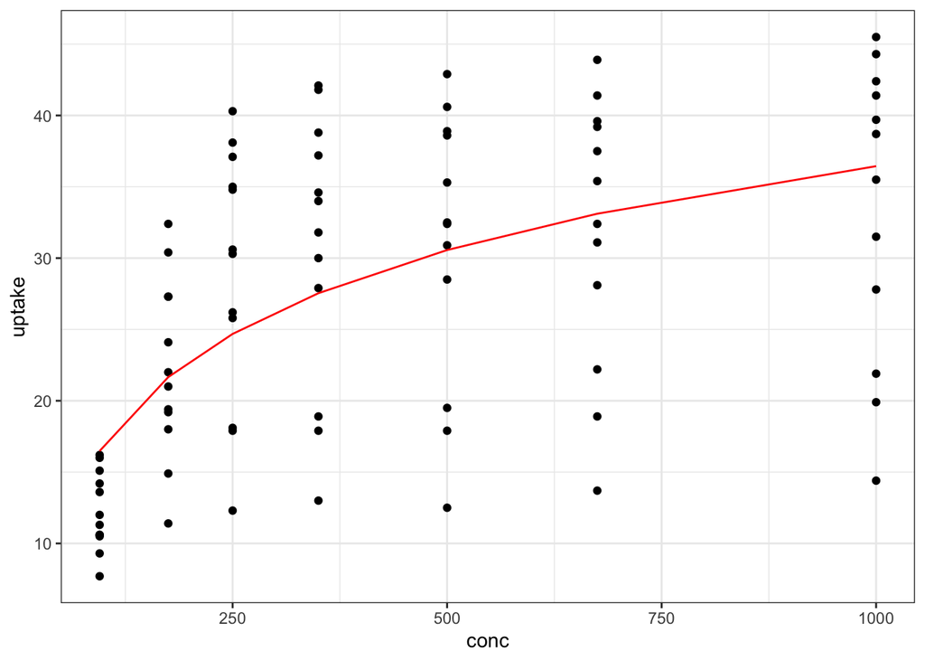

```r
em_1 %>%
  augment(newdata = CO2) %>%
  ggplot(aes(conc,uptake))+
  geom_point()+
  geom_line(aes(conc,.fitted), color = "red")+
  theme_bw()
```

We have the same issues as our first model. This is because there is more structure in our data that we have yet to address. We should fix this.

One of the main goals of the study underlying the data was the effect of the chilling treatment on CO2 uptake. As such, we should include it in our model.

```r
em_2 <- lm(uptake ~ log_conc*Treatment, data = CO2)
summary(em_2)
```

```
##
## Call:
## lm(formula = uptake ~ log_conc * Treatment, data = CO2)
##
## Residuals:
##     Min      1Q  Median      3Q     Max
## -17.352  -6.009  -1.506   6.649  16.497
##
## Coefficients:
##                           Estimate Std. Error t value Pr(>|t|)
## (Intercept)                -25.492      9.769  -2.610   0.0108 *
## log_conc                     9.646      1.665   5.794  1.3e-07 ***
## Treatmentchilled             6.670     13.815   0.483   0.6305
## log_conc:Treatmentchilled   -2.325      2.354  -0.987   0.3264
## ---
## Signif. codes:  0 '***' 0.001 '**' 0.01 '*' 0.05 '.' 0.1 ' ' 1
##
## Residual standard error: 8.099 on 80 degrees of freedom
## Multiple R-squared:  0.4594, Adjusted R-squared:  0.4391
## F-statistic: 22.66 on 3 and 80 DF,  p-value: 1.026e-10
```

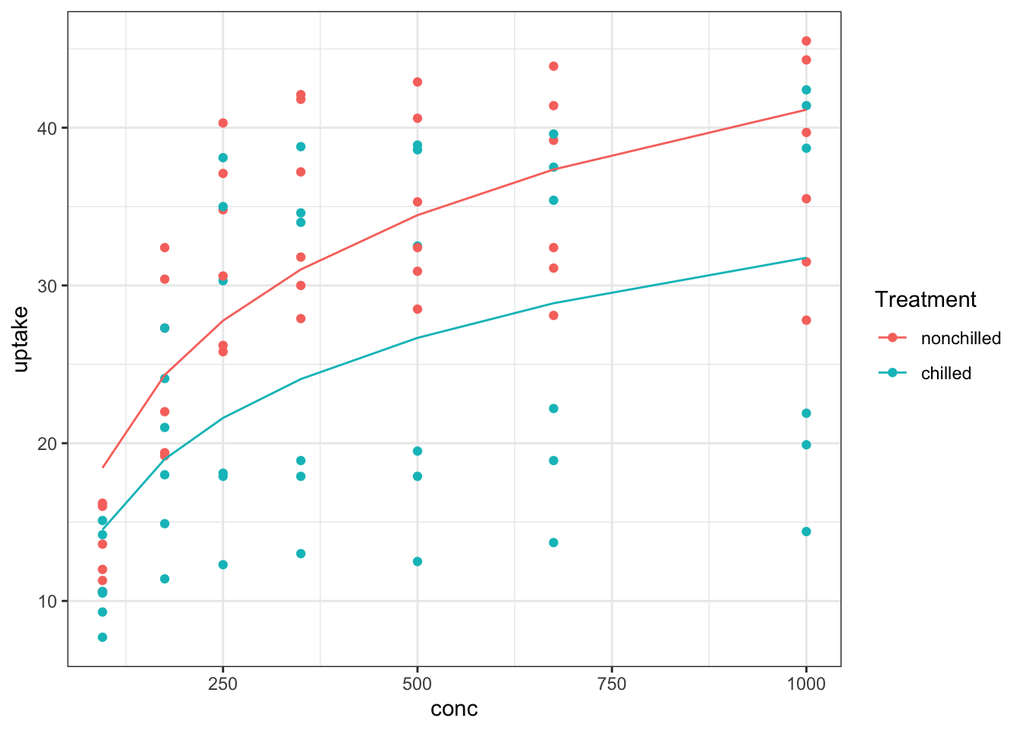

```r
em_2 %>%
  augment(newdata = CO2) %>%
  ggplot(aes(conc,uptake, color = Treatment))+
  geom_point()+
  geom_line(aes(conc,.fitted))+
  theme_bw()
```

This model gives us similar results as above, except now we have an non-siginificant Treatment and Treatment x Concentration terms. Our model is still not doing a great job of describing the data. Let’s see if removing the non-significant interaction term improves the situation.

```r
em_3 <- update(em_2, .~. - Treatment:log_conc)
summary(em_3)
```

```
##
## Call:
## lm(formula = uptake ~ log_conc + Treatment, data = CO2)
##
## Residuals:
##     Min      1Q  Median      3Q     Max
## -18.618  -5.740  -1.284   6.624  16.843
##
## Coefficients:
##                  Estimate Std. Error t value Pr(>|t|)
## (Intercept)       -18.727      6.963  -2.690 0.008683 **
## log_conc            8.484      1.177   7.208 2.67e-10 ***
## Treatmentchilled   -6.860      1.767  -3.882 0.000211 ***
## ---
## Signif. codes:  0 '***' 0.001 '**' 0.01 '*' 0.05 '.' 0.1 ' ' 1
##
## Residual standard error: 8.098 on 81 degrees of freedom
## Multiple R-squared:  0.4528, Adjusted R-squared:  0.4393
## F-statistic: 33.51 on 2 and 81 DF,  p-value: 2.488e-11
```

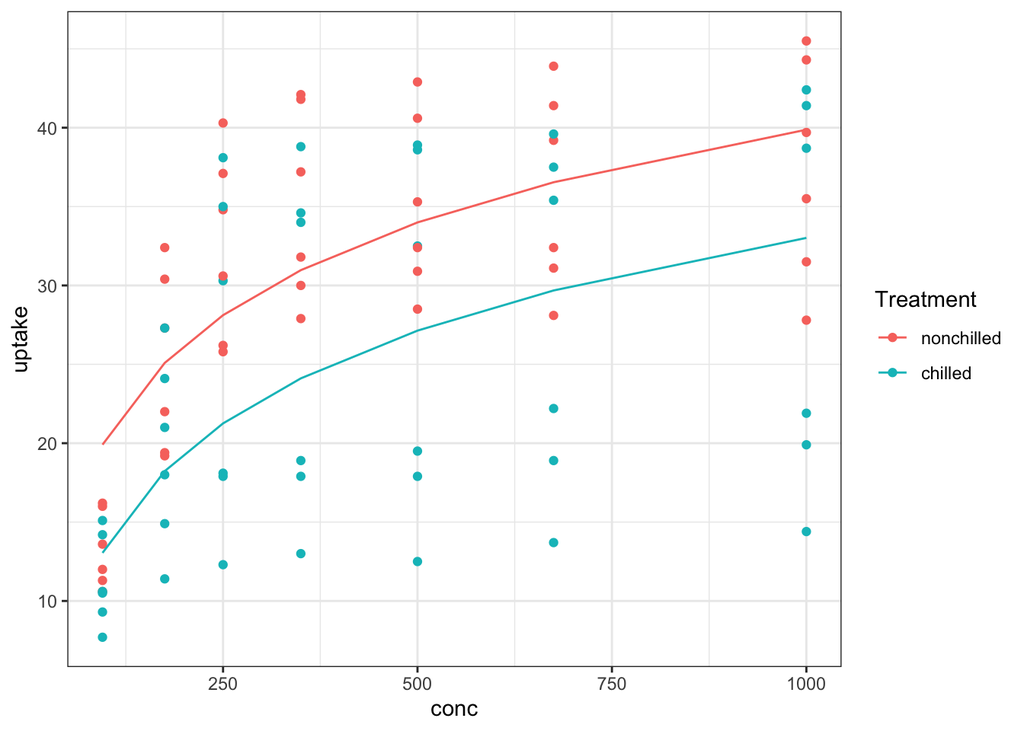

```r
em_3 %>%
  augment(newdata = CO2) %>%
  ggplot(aes(conc,uptake, color = Treatment))+
  geom_point()+
  geom_line(aes(conc,.fitted))+
  theme_bw()
```

Now the Treatment effect is significant in the model summary. However, the model is still not describing the data well. The residuals appear to be large

Now is a good time to note that the modelling process above is not in the most appropriate order. Generally, you will want to start by building a model that includes all of relevant terms and work backwards, removing terms that don’t contribute to the model’s ability to describe the data.

```r
model_1 <- lm(uptake ~ log_conc + Treatment + Type + log_conc:Type + Treatment:Type, data = CO2 )
summary(model_1)
```

```
##
## Call:
## lm(formula = uptake ~ log_conc + Treatment + Type + log_conc:Type +
##     Treatment:Type, data = CO2)
##
## Residuals:
##     Min      1Q  Median      3Q     Max
## -8.4974 -2.9076  0.1892  2.7548  9.6322
##
## Coefficients:
##                                  Estimate Std. Error t value Pr(>|t|)
## (Intercept)                      -28.8414     5.1777  -5.570 3.49e-07 ***
## log_conc                          11.0279     0.8753  12.599  < 2e-16 ***
## Treatmentchilled                  -3.5810     1.3141  -2.725 0.007935 **
## TypeMississippi                   20.2281     7.3224   2.762 0.007151 **
## log_conc:TypeMississippi          -5.0881     1.2379  -4.110 9.69e-05 ***
## Treatmentchilled:TypeMississippi  -6.5571     1.8584  -3.528 0.000705 ***
## ---
## Signif. codes:  0 '***' 0.001 '**' 0.01 '*' 0.05 '.' 0.1 ' ' 1
##
## Residual standard error: 4.258 on 78 degrees of freedom
## Multiple R-squared:  0.8543, Adjusted R-squared:  0.845
## F-statistic: 91.47 on 5 and 78 DF,  p-value: < 2.2e-16
```

```r
model_2 <- update(model_1, .~. - log_conc:Type)
anova(model_2,model_1) # p < 0.05, suggests term should be retained
```

```
## Analysis of Variance Table
##
## Model 1: uptake ~ log_conc + Treatment + Type + Treatment:Type
## Model 2: uptake ~ log_conc + Treatment + Type + log_conc:Type + Treatment:Type
##   Res.Df    RSS Df Sum of Sq      F    Pr(>F)
## 1     79 1720.7
## 2     78 1414.3  1    306.35 16.895 9.687e-05 ***
## ---
## Signif. codes:  0 '***' 0.001 '**' 0.01 '*' 0.05 '.' 0.1 ' ' 1
```

```r
model_3 <- update(model_1, .~. - Type:Treatment) # testing next interaction term
anova(model_3,model_1) # p < 0.05 suggests retaining term
```

```
## Analysis of Variance Table
##
## Model 1: uptake ~ log_conc + Treatment + Type + log_conc:Type
## Model 2: uptake ~ log_conc + Treatment + Type + log_conc:Type + Treatment:Type
##   Res.Df    RSS Df Sum of Sq      F    Pr(>F)
## 1     79 1640.1
## 2     78 1414.3  1    225.73 12.449 0.0007046 ***
## ---
## Signif. codes:  0 '***' 0.001 '**' 0.01 '*' 0.05 '.' 0.1 ' ' 1
```

```r
summary(model_2) # model 1 is our best model
```

```
##
## Call:
## lm(formula = uptake ~ log_conc + Treatment + Type + Treatment:Type,
##     data = CO2)
##
## Residuals:
##      Min       1Q   Median       3Q      Max
## -11.7166  -2.8960   0.5837   2.7621   8.8745
##
## Coefficients:
##                                  Estimate Std. Error t value Pr(>|t|)
## (Intercept)                      -14.0369     4.0768  -3.443 0.000923 ***
## log_conc                           8.4839     0.6783  12.507  < 2e-16 ***
## Treatmentchilled                  -3.5810     1.4403  -2.486 0.015017 *
## TypeMississippi                   -9.3810     1.4403  -6.513 6.26e-09 ***
## Treatmentchilled:TypeMississippi  -6.5571     2.0368  -3.219 0.001866 **
## ---
## Signif. codes:  0 '***' 0.001 '**' 0.01 '*' 0.05 '.' 0.1 ' ' 1
##
## Residual standard error: 4.667 on 79 degrees of freedom
## Multiple R-squared:  0.8227, Adjusted R-squared:  0.8138
## F-statistic: 91.67 on 4 and 79 DF,  p-value: < 2.2e-16
```

So our best model indicates that uptake is affected by concentration, type (plant origin), treatment, and the interaction b/w treatment and type and concentration and type. We didn’t really need to do the individual LRTests because the p-values in the summary call is equivalent to anovas() with individual terms dropped, but redundancy can be good.

Let’s visualize the model’s predictions

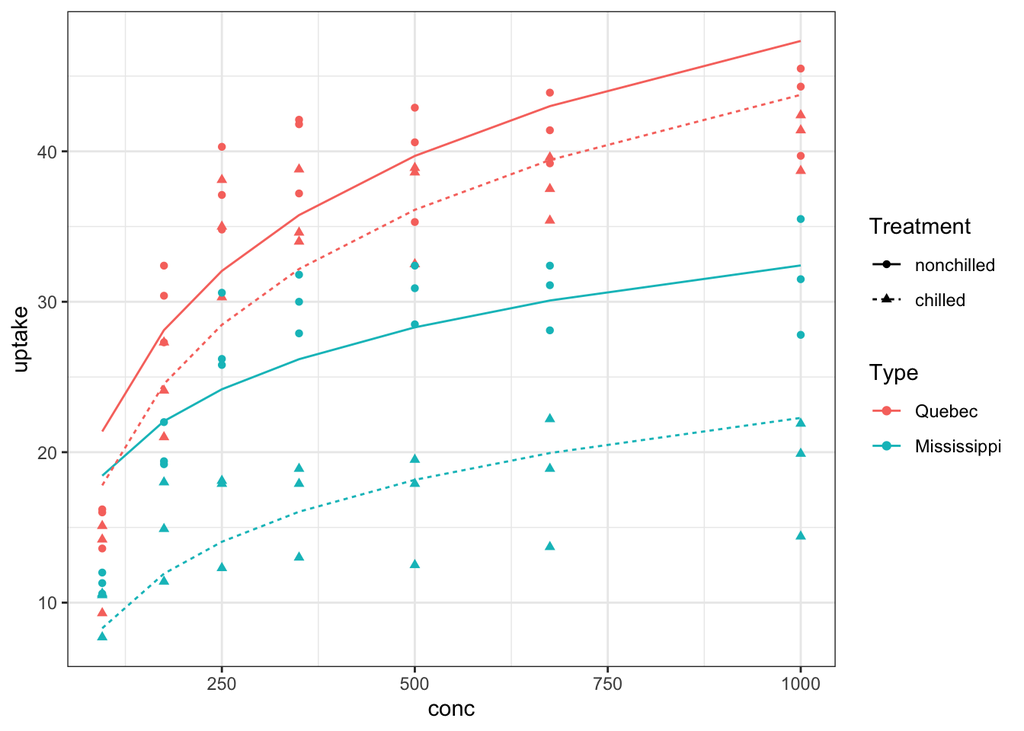

```r
model_1 %>%
  augment(newdata = CO2) %>%
  ggplot(aes(conc,uptake, color = Type, shape = Treatment))+
  geom_point()+
  geom_line(aes(conc,.fitted, linetype = Treatment))+
  theme_bw()
```

Looks like the model is doing a better job now. But its hard to differentiate Treatment in this graph. Let’s facet by Treatment to make it more readable. We ll also add std. error ribbons to visualize uncertainty.

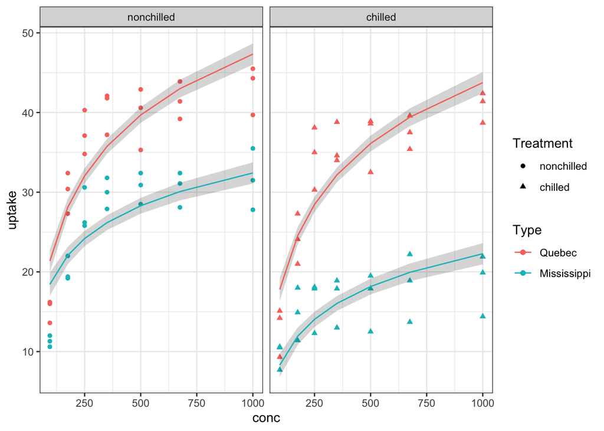

```r
model_1 %>%
  augment(newdata = CO2) %>%
  ggplot(aes(conc,uptake, color = Type, shape = Treatment))+
  geom_point()+
  geom_ribbon(aes(conc,ymin = .fitted - .se.fit, ymax = .fitted + .se.fit,
                  group = Type),
              alpha = 0.2, color = NA)+
  geom_line(aes(conc,.fitted))+
  facet_grid(~Treatment)+
  theme_bw()
```

This is great! However, there are an issue remaining… Because the data has multiple observations for each plant, our observations are not independant. This can invalidate our conclusions unless we address it.

The best way to address this non-independance is by using multi-level AKA mixed-effect modeling. This approach allows us to include individual plant identity as a random effect variable. The model will account for the variation due to differences between individual plants and allow us to account for the non-independance in our observations. It also lets us generalize our findings more broadly across the population and not just the specific plants in the experiment.

We will be using the lme4 package to fit the mixed-effect models. These types of models can get complicated and there are assumptions that must be met etc. We will touch on those but won’t linger to much more brevity.

```r
library(lme4);library(pbkrtest) # load the lme4 and pbkrtest and packages

# setup the model, same formula as above but also including plantID as a random effect w/ random intercept. We will use REML = T for now
lmm_1 <- lmer(uptake ~ log_conc + Treatment + Type + log_conc:Type + Treatment:Type + (1|Plant), data = CO2,REML = T )

summary(lmm_1)
```

```
## Linear mixed model fit by REML ['lmerMod']
## Formula:
## uptake ~ log_conc + Treatment + Type + log_conc:Type + Treatment:Type +
##     (1 | Plant)
##    Data: CO2
##
## REML criterion at convergence: 463.2
##
## Scaled residuals:
##      Min       1Q   Median       3Q      Max
## -2.24144 -0.70670  0.09881  0.65659  2.28327
##
## Random effects:
##  Groups   Name        Variance Std.Dev.
##  Plant    (Intercept)  2.741   1.656
##  Residual             16.164   4.020
## Number of obs: 84, groups:  Plant, 12
##
## Fixed effects:
##                                  Estimate Std. Error t value
## (Intercept)                      -28.8414     4.9812  -5.790
## log_conc                          11.0279     0.8264  13.344
## Treatmentchilled                  -3.5810     1.8350  -1.952
## TypeMississippi                   20.2281     7.0445   2.871
## log_conc:TypeMississippi          -5.0881     1.1688  -4.353
## Treatmentchilled:TypeMississippi  -6.5571     2.5950  -2.527
##
## Correlation of Fixed Effects:
##             (Intr) lg_cnc Trtmnt TypMss lg_:TM
## log_conc    -0.965
## Trtmntchlld -0.184  0.000
## TypeMsssspp -0.707  0.683  0.130
## lg_cnc:TypM  0.683 -0.707  0.000 -0.965
## Trtmntch:TM  0.130  0.000 -0.707 -0.184  0.000
```

The model output for the mixed-effect model looks similar to regular linear models, but with some exceptions.

We now have a random effects section that gives us information about variance components. In this case, the variance associated with the random effect planID is 2.74 and the residual variance is 16.16. We can calculate the intraclass correlation coefficent (ICC) also known as heritability or repeatability. This is simply the variance of the random effect divided by the sum of the random effect variance and the residual variance:

```r
vc <- as.data.frame(VarCorr(lmm_1)) # These are the model's variance components
vc
```

```
##        grp        var1 var2      vcov    sdcor
## 1    Plant (Intercept) <NA>  2.741366 1.655707
## 2 Residual        <NA> <NA> 16.164382 4.020495
```

```r
icc <- vc[1,"vcov"]/(vc[1,"vcov"] + vc[2,"vcov"])
icc # ICC = 0.15
```

```
## [1] 0.1450017
```

The ICC = 0.15, meaning that PlantID is responsible for 15% of the variance in the model.

We can either stop here and predict/validate the model - or - perform model simplification as we did with the regular linear models. Let’s try the latter route

```r
# First, we have to re-fit the model with ML (REML = F) in order to compare models with different fixed effect structures

lmm_1 <- lmer(uptake ~ log_conc + Treatment + Type + log_conc:Type + Treatment:Type + (1|Plant), data = CO2,REML = F)

summary(lmm_1)
```

```
## Linear mixed model fit by maximum likelihood  ['lmerMod']
## Formula:
## uptake ~ log_conc + Treatment + Type + log_conc:Type + Treatment:Type +
##     (1 | Plant)
##    Data: CO2
##
##      AIC      BIC   logLik deviance df.resid
##    490.6    510.1   -237.3    474.6       76
##
## Scaled residuals:
##     Min      1Q  Median      3Q     Max
## -2.2231 -0.7507  0.1467  0.6180  2.3597
##
## Random effects:
##  Groups   Name        Variance Std.Dev.
##  Plant    (Intercept)  1.122   1.059
##  Residual             15.715   3.964
## Number of obs: 84, groups:  Plant, 12
##
## Fixed effects:
##                                  Estimate Std. Error t value
## (Intercept)                      -28.8414     4.8589  -5.936
## log_conc                          11.0279     0.8149  13.533
## Treatmentchilled                  -3.5810     1.4982  -2.390
## TypeMississippi                   20.2281     6.8715   2.944
## log_conc:TypeMississippi          -5.0881     1.1524  -4.415
## Treatmentchilled:TypeMississippi  -6.5571     2.1188  -3.095
##
## Correlation of Fixed Effects:
##             (Intr) lg_cnc Trtmnt TypMss lg_:TM
## log_conc    -0.976
## Trtmntchlld -0.154  0.000
## TypeMsssspp -0.707  0.690  0.109
## lg_cnc:TypM  0.690 -0.707  0.000 -0.976
## Trtmntch:TM  0.109  0.000 -0.707 -0.154  0.000
```

```r
# Now we can fit a model that drops the interaction term with the lowest absolute t-value

lmm_2 <- lmer(uptake ~ log_conc + Treatment + Type + log_conc:Type + (1|Plant), data = CO2,REML = F)

# a normal anova() call will use the Wald d.f for the LRTest
anova(lmm_2,lmm_1)
```

```
## Data: CO2
## Models:
## lmm_2: uptake ~ log_conc + Treatment + Type + log_conc:Type + (1 | Plant)
## lmm_1: uptake ~ log_conc + Treatment + Type + log_conc:Type + Treatment:Type +
## lmm_1:     (1 | Plant)
##       Df    AIC    BIC  logLik deviance  Chisq Chi Df Pr(>Chisq)
## lmm_2  7 495.68 512.69 -240.84   481.68
## lmm_1  8 490.64 510.08 -237.32   474.64 7.0408      1   0.007967 **
## ---
## Signif. codes:  0 '***' 0.001 '**' 0.01 '*' 0.05 '.' 0.1 ' ' 1
```

```r
# we can also use KRmodcomp() to use the K-Rogers d.f, a slighlty more conservative method
KRmodcomp(lmm_2,lmm_1)
```

```
## F-test with Kenward-Roger approximation; computing time: 0.09 sec.
## large : uptake ~ log_conc + Treatment + Type + (1 | Plant) + log_conc:Type +
##     Treatment:Type
## small : uptake ~ log_conc + Treatment + Type + log_conc:Type + (1 | Plant)
##         stat    ndf    ddf F.scaling p.value
## Ftest 6.3849 1.0000 8.0000         1 0.03543 *
## ---
## Signif. codes:  0 '***' 0.001 '**' 0.01 '*' 0.05 '.' 0.1 ' ' 1
```

```r
# Both approaches retain the interaction.
# Now for the second interaction

lmm_3 <- lmer(uptake ~ log_conc + Treatment + Type + Treatment:Type + (1|Plant), data = CO2,REML = F)

anova(lmm_3,lmm_1)
```

```
## Data: CO2
## Models:
## lmm_3: uptake ~ log_conc + Treatment + Type + Treatment:Type + (1 |
## lmm_3:     Plant)
## lmm_1: uptake ~ log_conc + Treatment + Type + log_conc:Type + Treatment:Type +
## lmm_1:     (1 | Plant)
##       Df    AIC    BIC  logLik deviance  Chisq Chi Df Pr(>Chisq)
## lmm_3  7 505.89 522.90 -245.94   491.89
## lmm_1  8 490.64 510.08 -237.32   474.64 17.251      1  3.274e-05 ***
## ---
## Signif. codes:  0 '***' 0.001 '**' 0.01 '*' 0.05 '.' 0.1 ' ' 1
```

```r
KRmodcomp(lmm_3,lmm_1)
```

```
## F-test with Kenward-Roger approximation; computing time: 0.03 sec.
## large : uptake ~ log_conc + Treatment + Type + (1 | Plant) + log_conc:Type +
##     Treatment:Type
## small : uptake ~ log_conc + Treatment + Type + Treatment:Type + (1 |
##     Plant)
##         stat    ndf    ddf F.scaling   p.value
## Ftest 18.952  1.000 70.000         1 4.483e-05 ***
## ---
## Signif. codes:  0 '***' 0.001 '**' 0.01 '*' 0.05 '.' 0.1 ' ' 1
```

```r
# keep all interactions, lmm_1 is our best model
```

We could continue doing sequential LRTests to drum up p-values for each term, but the t-values in the summary output already suggest all terms are significant. Also, p-values are unreliable in mixed effect modeling. You’re better off visualizing and summarizing the model predictions and evaluating the fit to the data. The last option is parametric bootstapping which is an even more conservative alternative. We won’t go through that here.

Let’s look at our model’s predictions and evaluate the fit. First diagnostics

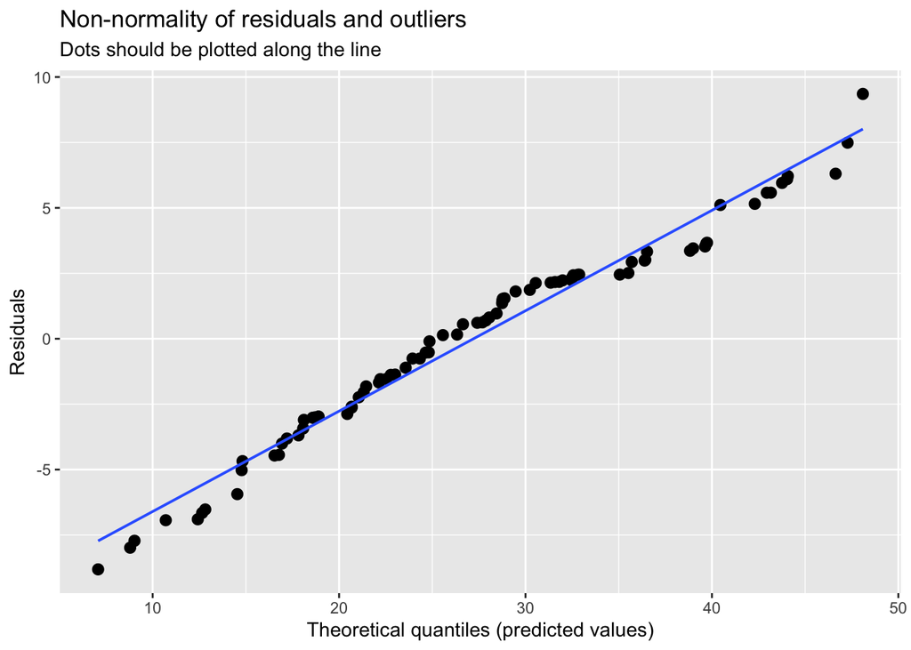

```
##
## [[2]]
## [[2]]$Plant
```

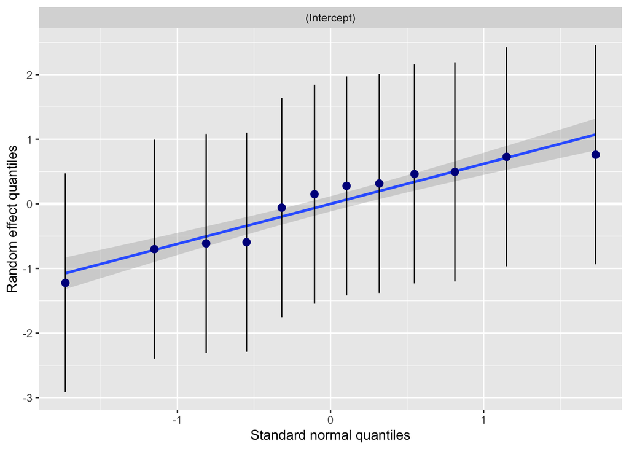

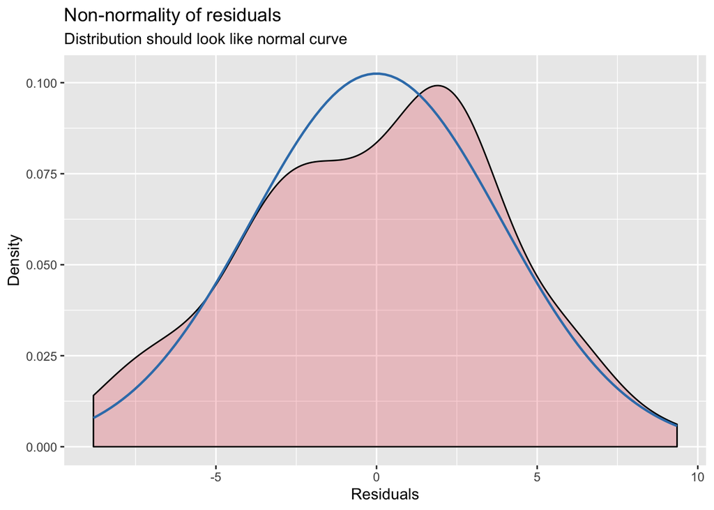

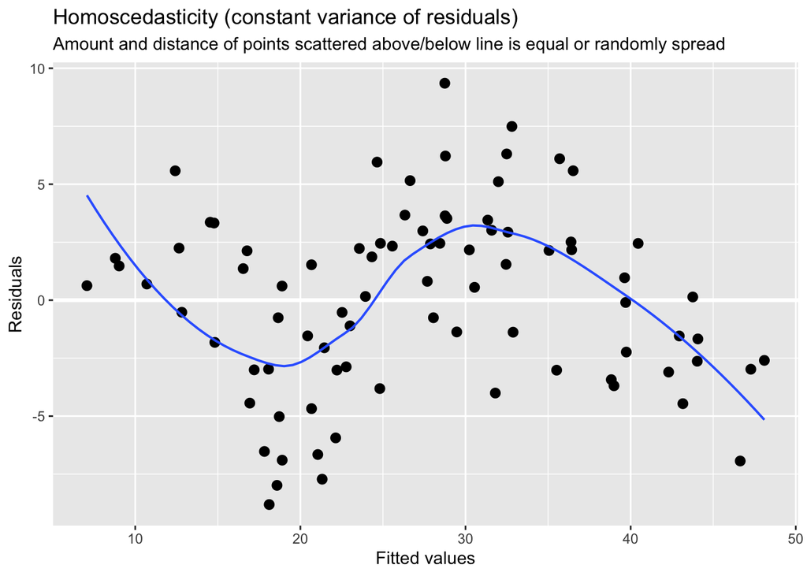

```r
library(sjPlot)
plot_model(lmm_1, type ="diag")
```

The diagnostics mostly check out. Normaility is there for the residuals and random effects. We do have some slight issues in homogeneity of variance, but this appears minor. There are alternative ways of specifying models to deal with this, but it isn’t too bad here and shouldn’t invalidate the model.

Now predictions:

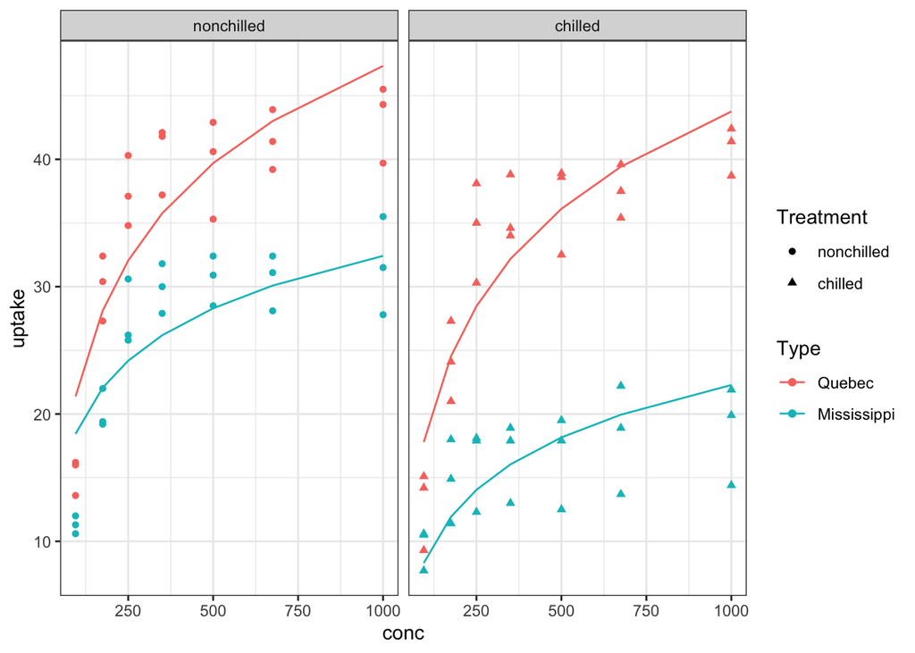

```r
# refit model with REML


lmm_1 <- lmer(uptake ~ log_conc + Treatment + Type + log_conc:Type + Treatment:Type + (1|Plant), data = CO2,REML =T)

lmm_1 %>%
  augment(newdata = CO2) %>%
  ggplot(aes(conc,uptake, color = Type, shape = Treatment))+
  geom_point()+
  geom_line(aes(conc,.fixed))+
  facet_grid(~Treatment)+
  theme_bw()
```

Let’s compare to our regular linear model

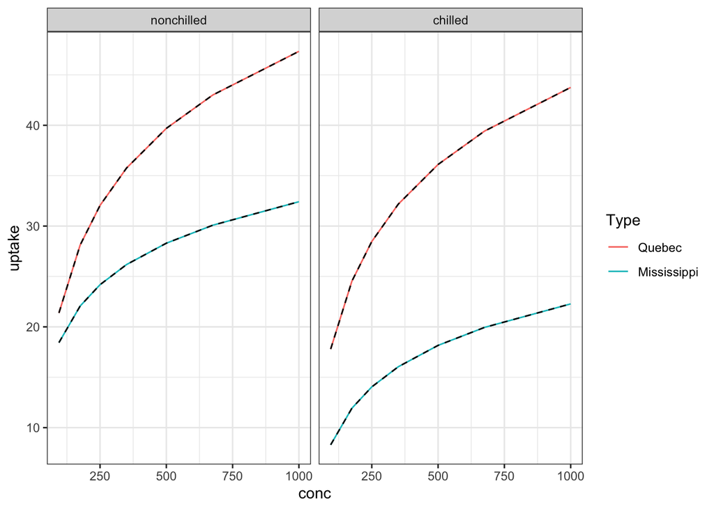

```r
reg <- augment(model_1, newdata = CO2)
lmm_1 %>%
  augment(newdata = CO2) %>%
  ggplot(aes(conc,uptake, color = Type, shape = Treatment))+
  geom_line(aes(conc,.fixed))+
  geom_line(data = reg, aes(conc,.fitted, group = Type), color = "black",linetype = "dashed")+
  facet_grid(~Treatment)+
  theme_bw()
```

The fixed predictions from the mixed-effect model are exactly the same as the regular linear model. This makes sense since the coeffeicents are the same.

Now let’s visualize how the random effect influence the intercepts

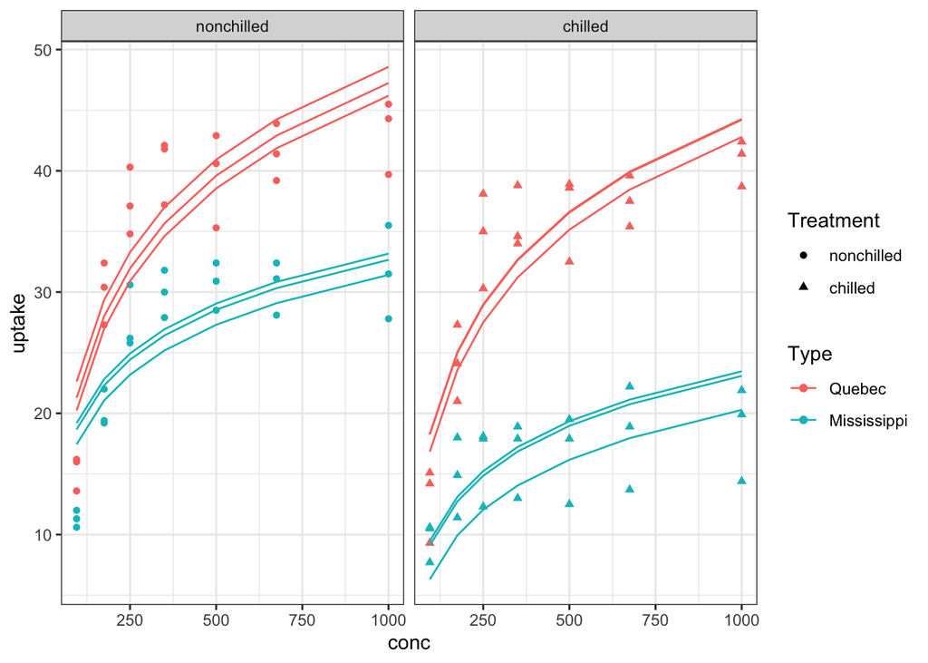

```r
lmm_1 %>%
  augment(newdata = CO2) %>%
  ggplot(aes(conc,uptake, color = Type, shape = Treatment))+
  geom_point()+
  geom_line(aes(conc,.fitted, group = Plant))+
  facet_grid(~Treatment)+
  theme_bw()
```

With individual lines for each Plant, we see how the random intercept plays out in the model. The lines in this case are pretty tightly grouped, this is reflect in the relatively small contribution of the random effect to the variation in the data (ICC = 0.15).

We can also evaluate if the model would be improved by including a random slope.

```r
lmm_4 <- lmer(uptake ~ log_conc + Treatment + Type + log_conc:Type + Treatment:Type + (1 +log_conc|Plant), data = CO2,REML = T)
```

```
## boundary (singular) fit: see ?isSingular
```

```r
# calling anova will automatically re-fit models with ML
anova(lmm_4,lmm_1) # not a lot of evidence that ranomd slope improves model
```

```
## refitting model(s) with ML (instead of REML)
```

```
## Data: CO2
## Models:
## lmm_1: uptake ~ log_conc + Treatment + Type + log_conc:Type + Treatment:Type +
## lmm_1:     (1 | Plant)
## lmm_4: uptake ~ log_conc + Treatment + Type + log_conc:Type + Treatment:Type +
## lmm_4:     (1 + log_conc | Plant)
##       Df    AIC    BIC  logLik deviance  Chisq Chi Df Pr(>Chisq)
## lmm_1  8 490.64 510.08 -237.32   474.64
## lmm_4 10 491.65 515.96 -235.83   471.65 2.9802      2     0.2254
```

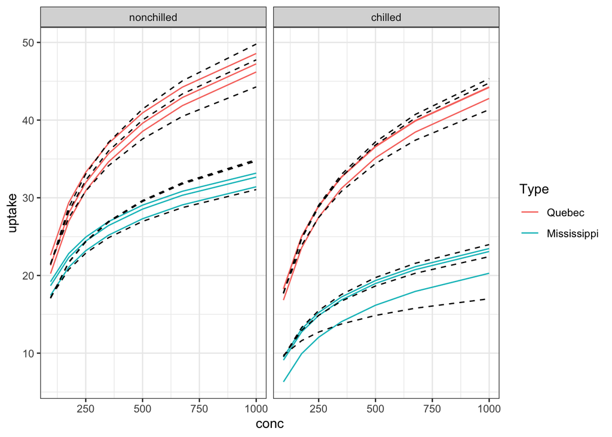

```r
# plotting, regardless
l4 <- augment(lmm_4, newdata = CO2)

lmm_1 %>%
  augment(newdata = CO2) %>%
  ggplot(aes(conc,uptake, color = Type, shape = Treatment))+
  geom_line(aes(conc,.fitted, group = Plant))+
  geom_line(data = l4,aes(conc,.fitted, group = Plant), color = "black", linetype = "dashed")+
  facet_grid(~Treatment)+
  theme_bw()
```

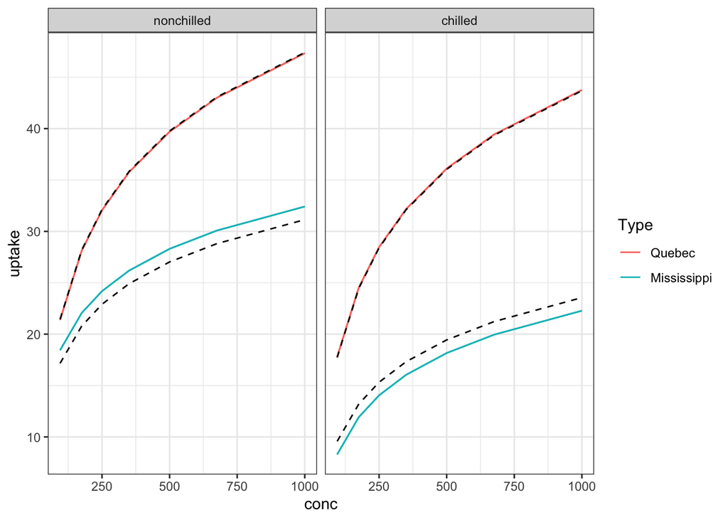

```r
lmm_1 %>%
  augment(newdata = CO2) %>%
  ggplot(aes(conc,uptake, color = Type, shape = Treatment))+
  geom_line(aes(conc,.fixed, group = Plant))+
  geom_line(data = l4,aes(conc,.fixed, group = Type), color = "black", linetype = "dashed")+
  facet_grid(~Treatment)+
  theme_bw()
```

So, the random slope changes the predictions of the fitted trajectories based on PlantID. It doesn’t change predicitons based on the fixed effect for plants form Quebec, but the Mississipppi plants have slight deviations in predictions.

Regardless, it doesn’t appear that adding a random slope term improves the model. So we can stick with our first model, and interpret. The outcome is the same as our regular linear model, only now we are accounting for random variaiton in the intercept do to PlantID, making our analyses more accurate and generalizable.